# The Gospel Is a Practice, Not a Belief

2026-01-22 · Shammah Chancellor

Most people—Christians and non-Christians alike—think they understand what Christianity is about.

Also on [Substack](https://shablag.substack.com/p/the-gospel-is-a-practice-not-a-belief)

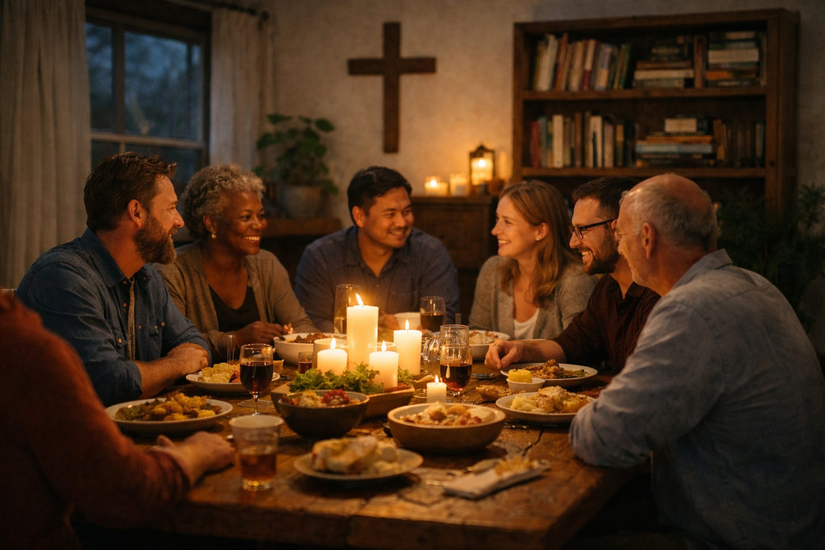

## The Gospel Is Not What We’ve Been Told

Most people—Christians and non-Christians alike—think they understand what Christianity is about.

Rules. Beliefs. Morality. Heaven and hell.

I thought I understood it too. I grew up around it, studied it seriously, left and came back more than once. I explored other traditions—Buddhism, Stoicism, secular humanism—not to dismiss Christianity, but to see whether anything else actually worked better.

What I found, slowly and with some resistance, is this:

If you strip away two thousand years of institutional buildup and cultural noise, something else appears. Something quieter, sharper, and more practical than most people expect.

**Jesus identified a specific mechanism that traps human beings in shame and conflict—and he offered a way of living that breaks it.**

He claimed that if people actually lived this way together, the world around them would begin to change.

Not symbolically. Not eventually. Now.

This is what he called the Kingdom of Heaven.

And I’ve come to believe he was right about the mechanism—even though I haven’t been able to fully test the practice at scale, because this was never meant to be done alone.

That’s part of why I’m writing this.

## What Gets Lost in Translation

When people hear “Christianity,” they think of an institution—and they’re not wrong to be wary.

Churches have excluded people. Protected power. Enabled abuse. History is clear on that.

But something took me years to see clearly:

**Every human institution does this.**

Buddhist monasteries developed rigid hierarchies that contradicted their teachings. Political revolutions hardened into tyrannies. Scientific institutions protected reputation over truth. Secular governments committed atrocities in the name of progress.

The failure mode isn’t uniquely Christian. It’s human.

What makes Christianity’s failures sting more is that Jesus explicitly warned they would happen. He spent much of his teaching criticizing religious leaders who “say but do not do,” who burden others while exempting themselves, who love status more than truth.

The church’s failures don’t disprove the Gospel.

They confirm its diagnosis.

So the question isn’t whether Christians have failed.

The question is: **What did Jesus actually teach—and what happens when people practice it?**

## The Kingdom of Heaven Is Not a Place

Jesus was surprisingly clear about this, even if theology later obscured it.

The Kingdom of Heaven is not somewhere you go after you die.

It is a pattern of relationship that becomes possible here, when people relate to one another differently.

He didn’t describe it through abstract doctrine. He described it through concrete behaviors:

- forgiving debts
- refusing retaliation
- telling the truth even when it’s costly
- caring for the vulnerable
- sharing meals across social boundaries
- refusing to exalt yourself over others

This wasn’t mysticism.

It was social architecture.

And at its center was a psychological insight that, after studying many other systems, I’ve come to believe is genuinely distinctive:

> **Human beings trap themselves—and each other—through judgment.**

## The Trap

Here’s how that mechanism works.

Think of someone you’ve judged harshly. Someone whose failure you condemned.

Now notice what that judgment does inside you.

It declares that *this kind of failure* is unacceptable. Which means that if *you* ever fail in that way, you deserve condemnation too.

So you hide that part of yourself. You perform its opposite. You build an identity around not being “that kind of person.”

But the hidden part doesn’t disappear. It becomes shame. Shame becomes fear. Fear makes honesty dangerous.

Now multiply this across everyone around you.

You get a social world where:

- people perform instead of being honest
- shame reproduces silently
- change feels threatening rather than possible
- relationships stay shallow because depth requires vulnerability
- conflict escalates because admitting fault risks rejection

**This is the trap.**

And once you see it, you see it everywhere: in politics, on social media, in workplaces, in therapy culture, in churches.

The judgment you aimed outward becomes a cage everyone lives inside.

Here’s the hard part: **you can’t think your way out of it.**

More judgment doesn’t fix the problem.

Judgment *is* the problem.

## Why “Judge Not” Changes Everything

When Jesus said, “Judge not, lest you be judged,” he wasn’t advocating moral relativism.

He was naming the mechanism—and how to break it.

When you stop judging others, something precise happens: you begin dismantling the internal structure that condemns you.

Shame loosens its grip—not because you reasoned it away, but because you stopped feeding the system that generates it.

And when people receive one another without requiring moral performance first, change becomes possible.

This is why Jesus consistently restored people *before* they changed their behavior.

Acceptance came first. Transformation followed.

Because shame does not produce growth.

Freedom does.

## Why This Is Different

I don’t say this casually. I’ve studied other systems carefully.

Here’s a concrete comparison.

Imagine someone betrays you—lies about you publicly, damages your reputation.

- **Buddhism** says: Recognize your attachment to outcomes. Let go, and suffering diminishes. The focus is internal.
- **Stoicism** says: They acted according to their nature and circumstances. Control your response. Maintain your inner fortress.
- **Jesus** says: Forgive them—not because they deserve it, and not to feel better, but because holding judgment traps *you* and perpetuates the same cycle that harmed you in the first place.

Do you see the difference?

Other systems help you manage your internal response to harm.

Jesus focuses on **stopping harm from replicating through a community**.

This is relational, not just personal.

And it only works when practiced together.

## The Honest Gap

I want to be direct about something.

I believe this mechanism is real. I believe Jesus identified something true about how humans trap one another and themselves. I believe the practice would work if people actually committed to it together.

But I haven’t seen it work at scale myself.

I’ve experienced parts of it—shame loosening, relationships softening, honesty becoming easier—but I’ve struggled to find others willing to practice it consistently, without turning it into ideology or hierarchy.

Jesus was clear about this too: this doesn’t work in isolation.

That gap—between understanding the mechanism and living it together—is why I’m writing.

## What This Could Become

Imagine small groups—five to eight people—meeting regularly, sharing meals, practicing non-judgment together.

No hierarchy. No doctrinal gatekeeping. No leader mediating the practice.

Just people committed to telling the truth about their lives, receiving one another without condemnation, and holding each other accountable without shame.

If this works the way Jesus suggested it might, something predictable would follow:

- Individuals would become freer to change.
- Relationships would stabilize around honesty instead of performance.
- Conflicts would resolve rather than metastasize.
- Communities would become more resilient, not more pure.

And if these groups quietly multiplied—not as an institution, but as a network—others would notice.

Not because of arguments or evangelism.

But because something real would be happening.

This isn’t utopia. It’s not guaranteed. It’s not quick.

But it’s a plausible path toward a different pattern of human life—one that doesn’t require perfect beliefs, only practiced care.

That’s the scale Jesus seemed to be pointing at.

## An Invitation

So here’s what I’m actually asking.

Try the practice.

Gather a small group. Share meals. Commit—explicitly—to suspending judgment with one another.

Not because nothing matters, but because judgment makes change impossible.

Do it consistently. Pay attention to what happens.

If it works, help others try it.

If it doesn’t, say so. Maybe the practice needs refinement. Maybe I’m wrong.

Either way, we learn something real.

We live in a world saturated with judgment and starving for honesty.

Jesus didn’t offer a belief system to defend.

He offered a way of living to try.

> *“The Kingdom of God is among you.”*

Not later.  
Not elsewhere.

**When we practice what he taught—together.**

If this resonates, reach out.  
I don’t want followers.  
I’m looking for fellow practitioners.

Read and subscribe on [Substack](https://shablag.substack.com/p/the-gospel-is-a-practice-not-a-belief)